# Yellowtail Rockfish

*Sebastes flavidus*

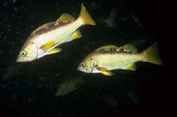

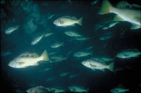

**Body color:** Grayish brown w/ brassy yellow wash becoming light gray on side and white ventrally; sides finely speckled w/ brown; several vague light blotches on back; fins dusky yellow. (Also see above underwater photos.)

**Peritoneum color:** light **Shape between eyes:** convex

**Counts:** D:XII-XIII,14-16, Ar:7-9, P1:17-19, GR:34-49, LLp:49-55, LLs:55-60, V:26

**Occurence:** Gulf of Alaska - Southern California

**Depth:** 549 meters **Size:** 66 cm **Species code:** 30240

**Similar species:**

- *Olive rockfish* - anal rays typically 9 (typically 7-8 in Yellowtail RF); pale areas on back more prominent; pectoral rays completely dark (often edged w/ pink in Yellowtail); pectoral rays typically 17 (typically 18 in Yellowtail RF); fin membranes dark
- *Widow rockfish* - anal fin w/ strong posterior slant (perpendicular in Yellowtail RF); body color dusky brown; pectoral, pelvic, and anal fins w/ black membranes (dusky in Yellowtail RF); mouth small, maxilla to midorbit (well past midorbit in Yellowtail RF)
- *Dusky rockfish* - peritoneum dark; dorsal rays typically 15-16 (typically 14 in Yellowtail RF); fin membranes dark
- *Black rockfish* - anal-fin margin rounded; body color black to blue-black, white ventrally; pectoral rays typically 19 (typically 18 in Yellowtail RF)

Back to Group

**Corrections:** If you see mistakes or want to suggest changes, please create an [issue](https://github.com/zoyafuso-NOAA/RACE_Survey_App/issues) on the source repository or

*reach out to Liz Dawson (Liz.Dawson AT noaa.gov).*